# ASM Chapter 3

code

julia

statistics

asm

ecology

Author

Dr Alun ap Rhisiart

Published

October 2, 2026

# About ASM

Applied Statistical Modelling for Ecologists (ASM) by Marc Kéry & Kenneth F. Kellner is a fantastic resource for quantitative ecologists looking to deepen their understanding of statistical modeling techniques. It is not as ‘advanced’ as Applied Hierarchical Modeling for Ecology vols 1 & 2 (AHM), or Integrated Population Models (IPM), but it provides a solid foundation for understanding and applying statistical models in ecological research. It takes a Rosetta Stone approach, with examples in JAGS, Stan, NIMBLE, TMB, and ‘DIY-MLE’. But, what statistical Rosetta Stone is complete without a Julia implementation? You could argue the same about a Python implementation, but although I commonly use Python for data engineering and Machine Learning tasks, I never use it for statistics, so I will leave that to someone else.

When I read for my BSc there was a course in statistics, and I enjoyed it because it was very practical. It was statistics that let me make sense of the data I collected and draw conclusions. Back then, it was all about using a cookbook, namely *Biometry* by Sokal & Rohlf. Inside the front and rear covers was a table, which you would consult to see, depending on number of variables and type of variables, which type of Null Hypothesis Significance Test (NHST) you should use: t-test, X-square, ANOVA, ANCOVA, etc. Each had its own table for looking up the significance level.

It was only when I started diving into Bayesian methods around 6 years ago that I realised these were pretty much all just variations of the same thing: linear models. What the ASM book emphasises is not only are the different frequentist methods related in this way (via GLM), but that Frequentist (Maximum Likelihood Estimation) and Bayesian methods are also related, via the likelihood function. This is the subject of Chapter 2, which I’ll write about later.

It is not my intention to repeat the explanations in ASM, but just to add Julia to the Rosetta stone approach, with some remarks where I was struck by something. Therefore, if you don’t have the book this section may be of little use to you. For those with the book, I give section numbers so that you can match up the Julia code with the corresponding sections in the book.

Of course, Julia has RCall, and anything done in the book can be done in a Julia program, combining the speed of Julia for data munging with the exact statistical capabilities of R. I enjoy working in R, but I also appreciate the performance and flexibility that Julia offers.

## Chapter 3

### Distributions

This chapter starts a discussion of the common distributions, namely Gaussian, Binomial/Bernoulli, Poisson, and Uniform. Interestingly, not Exponential, Laplace, Beta, Gamma, or half-Cauchy. That makes me interested to see the Bayesian models later in the book, to see what priors they are using.

To start we import the Julia packages, for functions that are built-in to R.

```julia
using Pkg

Pkg.add("GLM")
Pkg.add("DataFramesMeta")
Pkg.add("StatsPlots")

using GLM, DataFramesMeta, StatsBase, StatsPlots, CategoricalArrays, Distributions
```

### Quick Translation Summary

| R Function | Julia Equivalent | Purpose |
| --- | --- | --- |
| `rnorm(n, m, s)` | `rand(Normal(m, s), n)` | Random sampling (`r*`) |
| `dnorm(x, m, s)` | `pdf(Normal(m, s), x)` | Probability Density Function (`d*`) |
| `dnorm(…, log=TRUE)` | `logpdf(Normal(m, s), x)` | Log Probability Density |
| `pnorm(q, m, s)` | `cdf(Normal(m, s), q)` | Cumulative Distribution (`p*`) |
| `qnorm(p, m, s)` | `quantile(Normal(m, s), p)` | Quantiles (`q*`) |

#### 3.2.1 Gaussian Distribution

The chapter starts with the Gaussian, or Normal, distribution. This is determined by two parameters, the mean and the standard deviation. In Julia we can directly use Greek letters, not a romanised word.

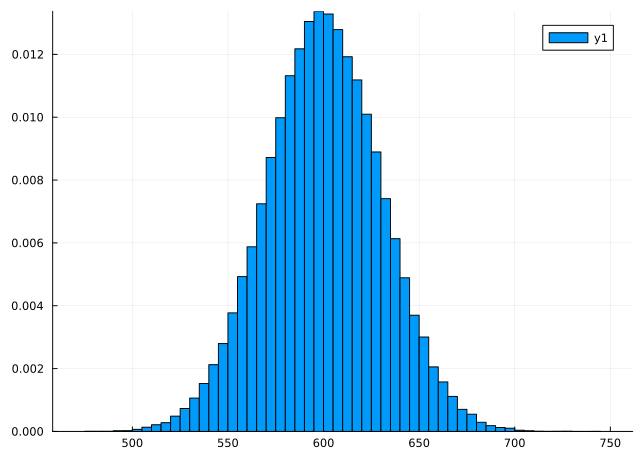

```julia
n = 100_000
μ = 600
σ = 30

sample = rand(Normal(μ, σ), n)
histogram(sample, bins=60, normalize=:pdf)
```

The rest follow a similar pattern, but note that the way you get a random sample is different from R. There are no ‘r*’, ’d*’, ‘p*’, or ’q*’ functions as in R; instead, you use the `rand` function for sampling.

#### 3.2.2 Uniform Distribution

The Uniform distribution is defined by two parameters which are the minimum and maximum values over which we want equal probability.

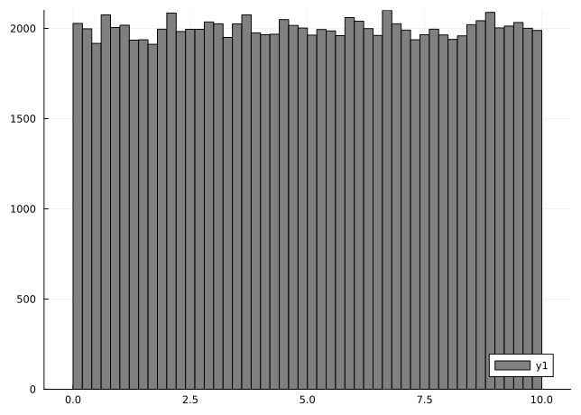

```julia
n = 100_000
a = lower_limit = 0
b = upper_limit = 10

sample = rand(Uniform(a, b), n)
histogram(sample, color = "grey", breaks=30)
```

#### 3.2.3 Binomial Distribution

A Bernoulli distribution occurs when a binary event can occur with probabilty p, such as a coin toss. If there is a succesion of Bernoulli trials, each with the same probability of success, this is a Binomial distribution. In the book they graph proportions rather than frequencies, and I do the same here. Note the difference from Poisson. Although both deal with an integer, perhaps a count, in the Binomial case there is a strict upper limit. For example in capture-recapture you can’t recapture more than you captured in the first place (the upper limit is the number of trials).

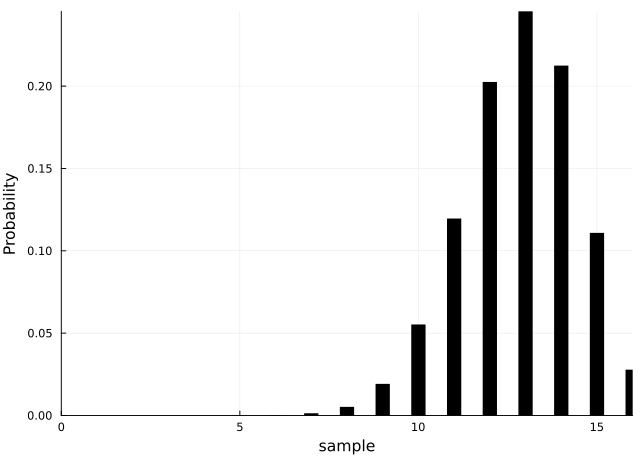

```julia
n = 100_000
N = 16
p = 0.8

# Draw random numbers
samp = rand(Binomial(N, p), n)

# Calculate relative frequencies (Equivalent to table(sample)/n)
pm = proportionmap(samp)

# Extract and sort the keys and values for plotting
x_vals = sort(collect(keys(pm)))
y_vals = [pm[k] for k in x_vals]

# Plot them
bar(x_vals, y_vals,
    bar_width=0.4,          # Equivalent to lwd = 20 (adjust to taste)
    color=(:black),
    linecolor=:transparent, # Removes borders to match R's flat lines
    xlims=(0, 16),
    ylabel="Probability",
    framestyle=:axes,
    legend=false,
    xlabel="sample"
)
```

Here is a simpler approach; we don’t have to expose the proportions calculations as histogram() can normalise by itself

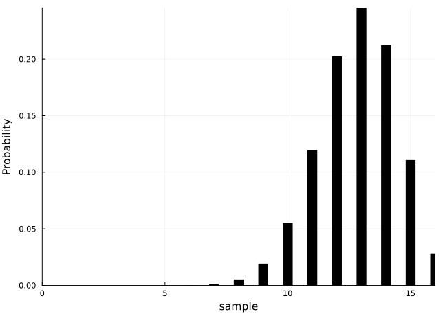

```julia
histogram(samp,
    normalize=:probability,
    bins=-0.5:1:16.5,       # Forces bins to center exactly on integers
    bar_width=0.4,
    color=(:black),
    linecolor=:transparent,
    xlims=(0, 16),
    ylabel="Probability",
    xlabel="sample",
    framestyle=:axes,
    legend=false
)
```

#### 3.2.4 Poisson Distribution

The Poisson distribution is very useful in ecology, where we are often dealing with counts with no upper limit and where the events occur independently.

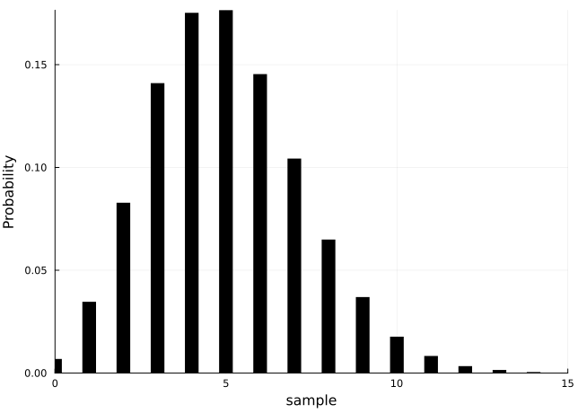

```julia
n = 100_000
λ = 5
samp = rand(Poisson(λ), n)

histogram(samp,
    normalize=:probability,
    bins=-0.5:1:15.5,       # Forces bins to center exactly on integers
    bar_width=0.4,
    color=(:black),
    linecolor=:transparent,
    xlims=(0, 15),
    ylabel="Probability",
    xlabel="sample",
    framestyle=:axes,
    legend=false
)
```

### 3.4 Linear Modelling of Covariate effects

This section shows beautifully how tests that I used to think were separate are actually all related. I must admit that I have never been exposed to design matrices before, and they make it crystal clear exactly what is happening.

We start with a toy dataset about the mass of snakes.

```julia
df = DataFrame(mass=[60, 80, 50, 70, 90, 110],
    pop=categorical([1, 1, 2, 2, 3, 3]),
    reg=categorical([1, 1, 1, 1, 2, 2]),
    hab=categorical([1, 2, 3, 1, 2, 3]),
    length=[40, 45, 39, 50, 52, 56])

show(df)
```

```
6×5 DataFrame
 Row │ mass   pop   reg   hab   length
     │ Int64  Cat…  Cat…  Cat…  Int64
─────┼─────────────────────────────────
   1 │    60  1     1     1         40
   2 │    80  1     1     2         45
   3 │    50  2     1     3         39
   4 │    70  2     1     1         50
   5 │    90  3     2     2         52
   6 │   110  3     2     3         56
```

In the book they use R’s model.matrix() function to show the design matrix, which is very valuable for really understanding what is going on, and how categorical variables and continous variables can coexist in the same model framework. There isn’t a direct counterpart to that in Julia, so we make one. R’s matrices can have column labels, whereas Julia’s standard matrices do not, so we wrap the matrix in a DataFrame to retain the column names. The default DataFrame column names are of the form ‘reg:1’, ‘pop:2’, etc so we replace the ‘:’ with an empty string to make them match the R function output.

```julia
function design_matrix_df(formula, df)
    mf = ModelFrame(formula, df)
    mm = modelmatrix(mf) # shorthand for ModelMatrix(mf).m
    col_names = replace.(string.(coefnames(mf.f.rhs)), ": " => "")
    return DataFrame(mm, col_names)
end
```

```
design_matrix_df (generic function with 1 method)
```

#### 3.4.1 Model of the mean

Next, we can fit the simple intercept-only model.

NB: the show() function in this code is just for Quarto, since I’m displaying the output of two lines of code per cell, not just the last one. It is not needed if you have Julia running in a script file. There you would just write `lm(@formula(mass ~ 1), df)` and it would output to the console.

```julia
show(lm(@formula(mass ~ 1), df))
show(design_matrix_df(@formula(mass ~ 1), df))
```

```
StatsModels.TableRegressionModel{LinearModel{GLM.LmResp{Vector{Float64}}, GLM.DensePredChol{Float64, LinearAlgebra.CholeskyPivoted{Float64, Matrix{Float64}, Vector{Int64}}}}, Matrix{Float64}}(GLM.LinearModel{GLM.LmResp{Vector{Float64}}, GLM.DensePredChol{Float64, LinearAlgebra.CholeskyPivoted{Float6…

Coefficients:
─────────────────────────────────────────────────────────────
      Coef.  Std. Error     t  Pr(>|t|)  Lower 95%  Upper 95%
─────────────────────────────────────────────────────────────
x1  76.6667     8.81917  8.69    0.0003    53.9963    99.3371
─────────────────────────────────────────────────────────────
, ModelFrame{@NamedTuple{mass::Vector{Int64}}, LinearModel}(mass ~ 1, StatsModels.Schema with 1 entry:
  mass => mass
, (mass = [60, 80, 50, 70, 90, 110],), LinearModel), ModelMatrix{Matrix{Float64}}([1.0; 1.0; … ; 1.0; 1.0;;], [1]))6×1 DataFrame
 Row │ (Intercept)
     │ Float64
─────┼─────────────
   1 │         1.0
   2 │         1.0
   3 │         1.0
   4 │         1.0
   5 │         1.0
   6 │         1.0
```

#### 3.4.2 Comparison of two groups

Next comes a simple comparison of two groups, here two different regions, using the default ‘effect’ parameterization.

```julia
show(lm(@formula(mass ~ reg), df))
show(design_matrix_df(@formula(mass ~ reg), df))
```

```
StatsModels.TableRegressionModel{LinearModel{GLM.LmResp{Vector{Float64}}, GLM.DensePredChol{Float64, LinearAlgebra.CholeskyPivoted{Float64, Matrix{Float64}, Vector{Int64}}}}, Matrix{Float64}}(GLM.LinearModel{GLM.LmResp{Vector{Float64}}, GLM.DensePredChol{Float64, LinearAlgebra.CholeskyPivoted{Float6…

Coefficients:
───────────────────────────────────────────────────────────
    Coef.  Std. Error     t  Pr(>|t|)  Lower 95%  Upper 95%
───────────────────────────────────────────────────────────
x1   65.0     6.61438  9.83    0.0006   46.6355     83.3645
x2   35.0    11.4564   3.06    0.0378    3.19183    66.8082
───────────────────────────────────────────────────────────
, ModelFrame{@NamedTuple{mass::Vector{Int64}, reg::CategoricalVector{Int64, UInt32, Int64, CategoricalValue{Int64, UInt32}, Union{}}}, LinearModel}(mass ~ 1 + reg, StatsModels.Schema with 2 entries:
  reg => reg
  mass => mass
, (mass = [60, 80, 50, 70, 90, 110], reg = CategoricalValue{Int64, UInt32}[CategoricalValue(CategoricalArrays.CategoricalPool{Int64, UInt32}([1, 2]), 1), CategoricalValue(CategoricalArrays.CategoricalPool{Int64, UInt32}([1, 2]), 1), CategoricalValue(CategoricalArrays.CategoricalPool{Int64, UInt32}([…
 Row │ (Intercept)  reg2
     │ Float64      Float64
─────┼──────────────────────
   1 │         1.0      0.0
   2 │         1.0      0.0
   3 │         1.0      0.0
   4 │         1.0      0.0
   5 │         1.0      1.0
   6 │         1.0      1.0
```

And the same using means parameterization

```julia
show(lm(@formula(mass ~ -1 + reg), df))
show(design_matrix_df(@formula(mass ~ -1 + reg), df))
```

```
StatsModels.TableRegressionModel{LinearModel{GLM.LmResp{Vector{Float64}}, GLM.DensePredChol{Float64, LinearAlgebra.CholeskyPivoted{Float64, Matrix{Float64}, Vector{Int64}}}}, Matrix{Float64}}(GLM.LinearModel{GLM.LmResp{Vector{Float64}}, GLM.DensePredChol{Float64, LinearAlgebra.CholeskyPivoted{Float6…

Coefficients:
────────────────────────────────────────────────────────────
    Coef.  Std. Error      t  Pr(>|t|)  Lower 95%  Upper 95%
────────────────────────────────────────────────────────────
x1   65.0     6.61438   9.83    0.0006    46.6355    83.3645
x2  100.0     9.35414  10.69    0.0004    74.0287   125.971
────────────────────────────────────────────────────────────
, ModelFrame{@NamedTuple{mass::Vector{Int64}, reg::CategoricalVector{Int64, UInt32, Int64, CategoricalValue{Int64, UInt32}, Union{}}}, LinearModel}(mass ~ 0 + reg, StatsModels.Schema with 2 entries:
  reg => reg
  mass => mass
, (mass = [60, 80, 50, 70, 90, 110], reg = CategoricalValue{Int64, UInt32}[CategoricalValue(CategoricalArrays.CategoricalPool{Int64, UInt32}([1, 2]), 1), CategoricalValue(CategoricalArrays.CategoricalPool{Int64, UInt32}([1, 2]), 1), CategoricalValue(CategoricalArrays.CategoricalPool{Int64, UInt32}([…
 Row │ reg1     reg2
     │ Float64  Float64
─────┼──────────────────
   1 │     1.0      0.0
   2 │     1.0      0.0
   3 │     1.0      0.0
   4 │     1.0      0.0
   5 │     0.0      1.0
   6 │     0.0      1.0
```

The outputs are equivalent. In the effect parameterization, the intercept represents the mean of the reference group, whereas in the means parameterization, each coefficient represents the mean of the corresponding group. So in effect parameterisation the average mass of snakes in the ‘default’ region 1 is 65, and region 2 we see ‘35’. That 35 is the *difference* from region one, not the mass itself. In means parameterization, the average mass of snakes in region 1 is still 65, but in region 2 it is 100, which is 65 + 35.

Effect parameterization is best when you are interested in the differences between groups, and means parameterization is best when you are interested in the actual group means.

#### 3.4.3 Simple linear regression

Next, we have one continuous covariate, the length, to fit to the mass. In R the design matrix can omit the LHS, but in Julia this cannot be done, we have to add a zero on the LHS if we want to omit the response.

```julia
show(lm(@formula(mass ~ length), df))
show(design_matrix_df(@formula(0 ~ length), df))
```

```
StatsModels.TableRegressionModel{LinearModel{GLM.LmResp{Vector{Float64}}, GLM.DensePredChol{Float64, LinearAlgebra.CholeskyPivoted{Float64, Matrix{Float64}, Vector{Int64}}}}, Matrix{Float64}}(GLM.LinearModel{GLM.LmResp{Vector{Float64}}, GLM.DensePredChol{Float64, LinearAlgebra.CholeskyPivoted{Float6…

Coefficients:
─────────────────────────────────────────────────────────────────
        Coef.  Std. Error      t  Pr(>|t|)   Lower 95%  Upper 95%
─────────────────────────────────────────────────────────────────
x1  -59.0661    31.0644    -1.90    0.1300  -145.315     27.1824
x2    2.88793    0.655234   4.41    0.0116     1.06871    4.70715
─────────────────────────────────────────────────────────────────
, ModelFrame{@NamedTuple{mass::Vector{Int64}, length::Vector{Int64}}, LinearModel}(mass ~ 1 + length, StatsModels.Schema with 2 entries:
  length => length
  mass => mass
, (mass = [60, 80, 50, 70, 90, 110], length = [40, 45, 39, 50, 52, 56]), LinearModel), ModelMatrix{Matrix{Float64}}([1.0 40.0; 1.0 45.0; … ; 1.0 52.0; 1.0 56.0], [1, 2]))6×2 DataFrame
 Row │ (Intercept)  length
     │ Float64      Float64
─────┼──────────────────────
   1 │         1.0     40.0
   2 │         1.0     45.0
   3 │         1.0     39.0
   4 │         1.0     50.0
   5 │         1.0     52.0
   6 │         1.0     56.0
```

Next, we look at a centered version. In R there is an I() operator. Generally, in formula syntax, +, -, and * characters have special meanings, so you need to wrap arithmetic expressions in I() to indicate they should be interpreted “as is”. In Julia, this does not exist. You can use any Julia function in the formula directly, but vectorised operations are not the same, so it is better to add a column with the centered values to the DataFrame. Rather than change the dataframe we use @chain to do it dynamically.

```julia
m_centered = @chain df begin
    @transform(:length_c = :length .- mean(:length))
    lm(@formula(mass ~ length_c), _)
end
```

```
StatsModels.TableRegressionModel{LinearModel{GLM.LmResp{Vector{Float64}}, GLM.DensePredChol{Float64, LinearAlgebra.CholeskyPivoted{Float64, Matrix{Float64}, Vector{Int64}}}}, Matrix{Float64}}

mass ~ 1 + length_c

Coefficients:
────────────────────────────────────────────────────────────────────────
                Coef.  Std. Error      t  Pr(>|t|)  Lower 95%  Upper 95%
────────────────────────────────────────────────────────────────────────
(Intercept)  76.6667     4.07441   18.82    <1e-04   65.3543    87.979
length_c      2.88793    0.655234   4.41    0.0116    1.06871    4.70715
────────────────────────────────────────────────────────────────────────
```

#### 3.4.4 Modeling the effects of one categorical covariate, or factor

We can fit a one-way ANOVA model using the categorical variable `pop`. The design matrix code is `model.matrix(~pop)`, but in StatsModels.jl it is not permitted to leave out the LHS entirely. We can use a zero:

```julia
show(design_matrix_df(@formula(0 ~ pop), df))
```

```
6×3 DataFrame
 Row │ (Intercept)  pop2     pop3
     │ Float64      Float64  Float64
─────┼───────────────────────────────
   1 │         1.0      0.0      0.0
   2 │         1.0      0.0      0.0
   3 │         1.0      1.0      0.0
   4 │         1.0      1.0      0.0
   5 │         1.0      0.0      1.0
   6 │         1.0      0.0      1.0
```

Compare with the `mass ~ pop` design matrix below. They are identical.

```julia
show(lm(@formula(mass ~ pop), df))
show(design_matrix_df(@formula(mass ~ pop), df))
```

```
StatsModels.TableRegressionModel{LinearModel{GLM.LmResp{Vector{Float64}}, GLM.DensePredChol{Float64, LinearAlgebra.CholeskyPivoted{Float64, Matrix{Float64}, Vector{Int64}}}}, Matrix{Float64}}(GLM.LinearModel{GLM.LmResp{Vector{Float64}}, GLM.DensePredChol{Float64, LinearAlgebra.CholeskyPivoted{Float6…

Coefficients:
────────────────────────────────────────────────────────────
    Coef.  Std. Error      t  Pr(>|t|)  Lower 95%  Upper 95%
────────────────────────────────────────────────────────────
x1   70.0     10.0      7.00    0.0060    38.1755   101.824
x2  -10.0     14.1421  -0.71    0.5305   -55.0066    35.0066
x3   30.0     14.1421   2.12    0.1240   -15.0066    75.0066
────────────────────────────────────────────────────────────
, ModelFrame{@NamedTuple{mass::Vector{Int64}, pop::CategoricalVector{Int64, UInt32, Int64, CategoricalValue{Int64, UInt32}, Union{}}}, LinearModel}(mass ~ 1 + pop, StatsModels.Schema with 2 entries:
  mass => mass
  pop => pop
, (mass = [60, 80, 50, 70, 90, 110], pop = CategoricalValue{Int64, UInt32}[CategoricalValue(CategoricalArrays.CategoricalPool{Int64, UInt32}([1, 2, 3]), 1), CategoricalValue(CategoricalArrays.CategoricalPool{Int64, UInt32}([1, 2, 3]), 1), CategoricalValue(CategoricalArrays.CategoricalPool{Int64, UIn…
 Row │ (Intercept)  pop2     pop3
     │ Float64      Float64  Float64
─────┼───────────────────────────────
   1 │         1.0      0.0      0.0
   2 │         1.0      0.0      0.0
   3 │         1.0      1.0      0.0
   4 │         1.0      1.0      0.0
   5 │         1.0      0.0      1.0
   6 │         1.0      0.0      1.0
```

This shows effect parameterisation, but we can also use means parameterisation by removing the intercept.

```julia
show(lm(@formula(mass ~ -1 + pop), df))
show(design_matrix_df(@formula(mass ~ -1 + pop), df))
```

```
StatsModels.TableRegressionModel{LinearModel{GLM.LmResp{Vector{Float64}}, GLM.DensePredChol{Float64, LinearAlgebra.CholeskyPivoted{Float64, Matrix{Float64}, Vector{Int64}}}}, Matrix{Float64}}(GLM.LinearModel{GLM.LmResp{Vector{Float64}}, GLM.DensePredChol{Float64, LinearAlgebra.CholeskyPivoted{Float6…

Coefficients:
────────────────────────────────────────────────────────────
    Coef.  Std. Error      t  Pr(>|t|)  Lower 95%  Upper 95%
────────────────────────────────────────────────────────────
x1   70.0        10.0   7.00    0.0060    38.1755   101.824
x2   60.0        10.0   6.00    0.0093    28.1755    91.8245
x3  100.0        10.0  10.00    0.0021    68.1755   131.824
────────────────────────────────────────────────────────────
, ModelFrame{@NamedTuple{mass::Vector{Int64}, pop::CategoricalVector{Int64, UInt32, Int64, CategoricalValue{Int64, UInt32}, Union{}}}, LinearModel}(mass ~ 0 + pop, StatsModels.Schema with 2 entries:
  mass => mass
  pop => pop
, (mass = [60, 80, 50, 70, 90, 110], pop = CategoricalValue{Int64, UInt32}[CategoricalValue(CategoricalArrays.CategoricalPool{Int64, UInt32}([1, 2, 3]), 1), CategoricalValue(CategoricalArrays.CategoricalPool{Int64, UInt32}([1, 2, 3]), 1), CategoricalValue(CategoricalArrays.CategoricalPool{Int64, UIn…
 Row │ pop1     pop2     pop3
     │ Float64  Float64  Float64
─────┼───────────────────────────
   1 │     1.0      0.0      0.0
   2 │     1.0      0.0      0.0
   3 │     0.0      1.0      0.0
   4 │     0.0      1.0      0.0
   5 │     0.0      0.0      1.0
   6 │     0.0      0.0      1.0
```

**Note**

Note that in R you can place the -1 anywhere, but StatsModels.jl seems to object if it isn’t at the beginning of the formula.

#### 3.4.5 Modeling effects of two factors

We can fit a two-way ANOVA model using the categorical variables `hab` and `reg` (habitat and region).

```julia
show(lm(@formula(mass ~ reg + hab), df))
show(design_matrix_df(@formula(mass ~ reg + hab), df))
```

```
StatsModels.TableRegressionModel{LinearModel{GLM.LmResp{Vector{Float64}}, GLM.DensePredChol{Float64, LinearAlgebra.CholeskyPivoted{Float64, Matrix{Float64}, Vector{Int64}}}}, Matrix{Float64}}(GLM.LinearModel{GLM.LmResp{Vector{Float64}}, GLM.DensePredChol{Float64, LinearAlgebra.CholeskyPivoted{Float6…

Coefficients:
────────────────────────────────────────────────────────────
    Coef.  Std. Error      t  Pr(>|t|)  Lower 95%  Upper 95%
────────────────────────────────────────────────────────────
x1   65.0     12.9904   5.00    0.0377     9.1069   120.893
x2   35.0     18.3712   1.91    0.1970   -44.0448   114.045
x3    2.5     20.5396   0.12    0.9143   -85.8747    90.8747
x4   -2.5     20.5396  -0.12    0.9143   -90.8747    85.8747
────────────────────────────────────────────────────────────
, ModelFrame{@NamedTuple{mass::Vector{Int64}, reg::CategoricalVector{Int64, UInt32, Int64, CategoricalValue{Int64, UInt32}, Union{}}, hab::CategoricalVector{Int64, UInt32, Int64, CategoricalValue{Int64, UInt32}, Union{}}}, LinearModel}(mass ~ 1 + reg + hab, StatsModels.Schema with 3 entries:
  reg => reg
  mass => mass
  hab => hab
, (mass = [60, 80, 50, 70, 90, 110], reg = CategoricalValue{Int64, UInt32}[CategoricalValue(CategoricalArrays.CategoricalPool{Int64, UInt32}([1, 2]), 1), CategoricalValue(CategoricalArrays.CategoricalPool{Int64, UInt32}([1, 2]), 1), CategoricalValue(CategoricalArrays.CategoricalPool{Int64, UInt32}([…
 Row │ (Intercept)  reg2     hab2     hab3
     │ Float64      Float64  Float64  Float64
─────┼────────────────────────────────────────
   1 │         1.0      0.0      0.0      0.0
   2 │         1.0      0.0      1.0      0.0
   3 │         1.0      0.0      0.0      1.0
   4 │         1.0      0.0      0.0      0.0
   5 │         1.0      1.0      1.0      0.0
   6 │         1.0      1.0      0.0      1.0
```

Adding interaction effects

```julia
show(lm(@formula(mass ~ reg * hab), df))
show(design_matrix_df(@formula(mass ~ reg * hab), df))
```

```
StatsModels.TableRegressionModel{LinearModel{GLM.LmResp{Vector{Float64}}, GLM.DensePredChol{Float64, LinearAlgebra.CholeskyPivoted{Float64, Matrix{Float64}, Vector{Int64}}}}, Matrix{Float64}}(GLM.LinearModel{GLM.LmResp{Vector{Float64}}, GLM.DensePredChol{Float64, LinearAlgebra.CholeskyPivoted{Float6…

Coefficients:
──────────────────────────────────────────────────────────────
    Coef.  Std. Error       t  Pr(>|t|)   Lower 95%  Upper 95%
──────────────────────────────────────────────────────────────
x1   65.0     5.0       13.00    0.0489     1.46898    128.531
x2   60.0    10.0        6.00    0.1051   -67.062      187.062
x3   15.0     8.66025    1.73    0.3333   -95.039      125.039
x4  -15.0     8.66025   -1.73    0.3333  -125.039       95.039
x5  -50.0    14.1421    -3.54    0.1755  -229.693      129.693
x6    0.0   NaN        NaN       NaN      NaN          NaN
──────────────────────────────────────────────────────────────
, ModelFrame{@NamedTuple{mass::Vector{Int64}, reg::CategoricalVector{Int64, UInt32, Int64, CategoricalValue{Int64, UInt32}, Union{}}, hab::CategoricalVector{Int64, UInt32, Int64, CategoricalValue{Int64, UInt32}, Union{}}}, LinearModel}(mass ~ 1 + reg + hab + reg & hab, StatsModels.Schema with 3 entr…
  reg => reg
  mass => mass
  hab => hab
, (mass = [60, 80, 50, 70, 90, 110], reg = CategoricalValue{Int64, UInt32}[CategoricalValue(CategoricalArrays.CategoricalPool{Int64, UInt32}([1, 2]), 1), CategoricalValue(CategoricalArrays.CategoricalPool{Int64, UInt32}([1, 2]), 1), CategoricalValue(CategoricalArrays.CategoricalPool{Int64, UInt32}([…
 Row │ (Intercept)  reg2     hab2     hab3     reg2 & hab2  reg2 & hab3
     │ Float64      Float64  Float64  Float64  Float64      Float64
─────┼──────────────────────────────────────────────────────────────────
   1 │         1.0      0.0      0.0      0.0          0.0          0.0
   2 │         1.0      0.0      1.0      0.0          0.0          0.0
   3 │         1.0      0.0      0.0      1.0          0.0          0.0
   4 │         1.0      0.0      0.0      0.0          0.0          0.0
   5 │         1.0      1.0      1.0      0.0          1.0          0.0
   6 │         1.0      1.0      0.0      1.0          0.0          1.0
```

**Note**

Note that R uses `:` for interaction terms without main effects, whereas Julia uses `&`.

```julia
show(lm(@formula(mass ~ reg & hab), df))
show(design_matrix_df(@formula(mass ~ reg & hab), df))
```

```
StatsModels.TableRegressionModel{LinearModel{GLM.LmResp{Vector{Float64}}, GLM.DensePredChol{Float64, LinearAlgebra.CholeskyPivoted{Float64, Matrix{Float64}, Vector{Int64}}}}, Matrix{Float64}}(GLM.LinearModel{GLM.LmResp{Vector{Float64}}, GLM.DensePredChol{Float64, LinearAlgebra.CholeskyPivoted{Float6…

Coefficients:
─────────────────────────────────────────────────────────────
    Coef.  Std. Error       t  Pr(>|t|)  Lower 95%  Upper 95%
─────────────────────────────────────────────────────────────
x1  110.0     7.07107   15.56    0.0409    20.1536    199.846
x2  -45.0     8.66025   -5.20    0.1210  -155.039      65.039
x3    0.0   NaN        NaN       NaN      NaN         NaN
x4  -30.0    10.0       -3.00    0.2048  -157.062      97.062
x5  -20.0    10.0       -2.00    0.2952  -147.062     107.062
x6  -60.0    10.0       -6.00    0.1051  -187.062      67.062
x7    0.0   NaN        NaN       NaN      NaN         NaN
─────────────────────────────────────────────────────────────
, ModelFrame{@NamedTuple{mass::Vector{Int64}, reg::CategoricalVector{Int64, UInt32, Int64, CategoricalValue{Int64, UInt32}, Union{}}, hab::CategoricalVector{Int64, UInt32, Int64, CategoricalValue{Int64, UInt32}, Union{}}}, LinearModel}(mass ~ 1 + reg & hab, StatsModels.Schema with 3 entries:
  reg => reg
  mass => mass
  hab => hab
, (mass = [60, 80, 50, 70, 90, 110], reg = CategoricalValue{Int64, UInt32}[CategoricalValue(CategoricalArrays.CategoricalPool{Int64, UInt32}([1, 2]), 1), CategoricalValue(CategoricalArrays.CategoricalPool{Int64, UInt32}([1, 2]), 1), CategoricalValue(CategoricalArrays.CategoricalPool{Int64, UInt32}([…
 Row │ (Intercept)  reg1 & hab1  reg2 & hab1  reg1 & hab2  reg2 & hab2  reg1 & ⋯
     │ Float64      Float64      Float64      Float64      Float64      Float6 ⋯
─────┼──────────────────────────────────────────────────────────────────────────
   1 │         1.0          1.0          0.0          0.0          0.0         ⋯
   2 │         1.0          0.0          0.0          1.0          0.0
   3 │         1.0          0.0          0.0          0.0          0.0
   4 │         1.0          1.0          0.0          0.0          0.0
   5 │         1.0          0.0          0.0          0.0          1.0         ⋯
   6 │         1.0          0.0          0.0          0.0          0.0
                                                               2 columns omitted
```

Finally, in this section, we have means parameterization of the interaction-effects model.

```julia
show(lm(@formula(mass ~ -1 + reg & hab), df))
show(design_matrix_df(@formula(mass ~ -1 + reg & hab), df))
```

```
StatsModels.TableRegressionModel{LinearModel{GLM.LmResp{Vector{Float64}}, GLM.DensePredChol{Float64, LinearAlgebra.CholeskyPivoted{Float64, Matrix{Float64}, Vector{Int64}}}}, Matrix{Float64}}(GLM.LinearModel{GLM.LmResp{Vector{Float64}}, GLM.DensePredChol{Float64, LinearAlgebra.CholeskyPivoted{Float6…

Coefficients:
──────────────────────────────────────────────────────────────
    Coef.  Std. Error       t  Pr(>|t|)   Lower 95%  Upper 95%
──────────────────────────────────────────────────────────────
x1   65.0     5.0       13.00    0.0489    1.46898     128.531
x2    0.0   NaN        NaN       NaN     NaN           NaN
x3   80.0     7.07107   11.31    0.0561   -9.84644     169.846
x4   90.0     7.07107   12.73    0.0499    0.153565    179.846
x5   50.0     7.07107    7.07    0.0894  -39.8464      139.846
x6  110.0     7.07107   15.56    0.0409   20.1536      199.846
──────────────────────────────────────────────────────────────
, ModelFrame{@NamedTuple{mass::Vector{Int64}, reg::CategoricalVector{Int64, UInt32, Int64, CategoricalValue{Int64, UInt32}, Union{}}, hab::CategoricalVector{Int64, UInt32, Int64, CategoricalValue{Int64, UInt32}, Union{}}}, LinearModel}(mass ~ 0 + reg & hab, StatsModels.Schema with 3 entries:
  reg => reg
  mass => mass
  hab => hab
, (mass = [60, 80, 50, 70, 90, 110], reg = CategoricalValue{Int64, UInt32}[CategoricalValue(CategoricalArrays.CategoricalPool{Int64, UInt32}([1, 2]), 1), CategoricalValue(CategoricalArrays.CategoricalPool{Int64, UInt32}([1, 2]), 1), CategoricalValue(CategoricalArrays.CategoricalPool{Int64, UInt32}([…
 Row │ reg1 & hab1  reg2 & hab1  reg1 & hab2  reg2 & hab2  reg1 & hab3  reg2 & ⋯
     │ Float64      Float64      Float64      Float64      Float64      Float6 ⋯
─────┼──────────────────────────────────────────────────────────────────────────
   1 │         1.0          0.0          0.0          0.0          0.0         ⋯
   2 │         0.0          0.0          1.0          0.0          0.0
   3 │         0.0          0.0          0.0          0.0          1.0
   4 │         1.0          0.0          0.0          0.0          0.0
   5 │         0.0          0.0          0.0          1.0          0.0         ⋯
   6 │         0.0          0.0          0.0          0.0          0.0
                                                                1 column omitted
```

#### 3.4.6 Modeling the effects of a factor and a continuous covariate

In an Analysis of Covariance (ANCOVA) we have both categorical and continuous covariates. In this case we have two covariates, one categorical and one continuous.

```julia
show(lm(@formula(mass ~ pop + length), df))
show(design_matrix_df(@formula(mass ~ pop + length), df))
```

```
StatsModels.TableRegressionModel{LinearModel{GLM.LmResp{Vector{Float64}}, GLM.DensePredChol{Float64, LinearAlgebra.CholeskyPivoted{Float64, Matrix{Float64}, Vector{Int64}}}}, Matrix{Float64}}(GLM.LinearModel{GLM.LmResp{Vector{Float64}}, GLM.DensePredChol{Float64, LinearAlgebra.CholeskyPivoted{Float6…

Coefficients:
─────────────────────────────────────────────────────────────────
        Coef.  Std. Error      t  Pr(>|t|)   Lower 95%  Upper 95%
─────────────────────────────────────────────────────────────────
x1  -34.9383     34.7899   -1.00    0.4210  -184.627    114.751
x2  -14.9383      7.46378  -2.00    0.1833   -47.0523    17.1758
x3    1.60494    11.8221    0.14    0.9044   -49.2613    52.4712
x4    2.46914     0.80956   3.05    0.0928    -1.01412    5.95239
─────────────────────────────────────────────────────────────────
, ModelFrame{@NamedTuple{mass::Vector{Int64}, pop::CategoricalVector{Int64, UInt32, Int64, CategoricalValue{Int64, UInt32}, Union{}}, length::Vector{Int64}}, LinearModel}(mass ~ 1 + pop + length, StatsModels.Schema with 3 entries:
  length => length
  mass => mass
  pop => pop
, (mass = [60, 80, 50, 70, 90, 110], pop = CategoricalValue{Int64, UInt32}[CategoricalValue(CategoricalArrays.CategoricalPool{Int64, UInt32}([1, 2, 3]), 1), CategoricalValue(CategoricalArrays.CategoricalPool{Int64, UInt32}([1, 2, 3]), 1), CategoricalValue(CategoricalArrays.CategoricalPool{Int64, UIn…
 Row │ (Intercept)  pop2     pop3     length
     │ Float64      Float64  Float64  Float64
─────┼────────────────────────────────────────
   1 │         1.0      0.0      0.0     40.0
   2 │         1.0      0.0      0.0     45.0
   3 │         1.0      1.0      0.0     39.0
   4 │         1.0      1.0      0.0     50.0
   5 │         1.0      0.0      1.0     52.0
   6 │         1.0      0.0      1.0     56.0
```

And the same with interactions

```julia
fm = lm(@formula(mass ~ pop * length), df)
show(fm)
show(design_matrix_df(@formula(mass ~ pop * length), df))
```

```
StatsModels.TableRegressionModel{LinearModel{GLM.LmResp{Vector{Float64}}, GLM.DensePredChol{Float64, LinearAlgebra.CholeskyPivoted{Float64, Matrix{Float64}, Vector{Int64}}}}, Matrix{Float64}}(GLM.LinearModel{GLM.LmResp{Vector{Float64}}, GLM.DensePredChol{Float64, LinearAlgebra.CholeskyPivoted{Float6…

Coefficients:
─────────────────────────────────────────────────────────────────
         Coef.  Std. Error      t  Pr(>|t|)  Lower 95%  Upper 95%
─────────────────────────────────────────────────────────────────
x1  -100.0             Inf  -0.00    1.0000       -Inf        Inf
x2    79.0909          Inf   0.00    1.0000       -Inf        Inf
x3   -70.0             Inf  -0.00    1.0000       -Inf        Inf
x4     4.0             Inf   0.00    1.0000       -Inf        Inf
x5    -2.18182         Inf  -0.00    1.0000       -Inf        Inf
x6     1.0             Inf   0.00    1.0000       -Inf        Inf
─────────────────────────────────────────────────────────────────
, ModelFrame{@NamedTuple{mass::Vector{Int64}, pop::CategoricalVector{Int64, UInt32, Int64, CategoricalValue{Int64, UInt32}, Union{}}, length::Vector{Int64}}, LinearModel}(mass ~ 1 + pop + length + pop & length, StatsModels.Schema with 3 entries:
  length => length
  mass => mass
  pop => pop
, (mass = [60, 80, 50, 70, 90, 110], pop = CategoricalValue{Int64, UInt32}[CategoricalValue(CategoricalArrays.CategoricalPool{Int64, UInt32}([1, 2, 3]), 1), CategoricalValue(CategoricalArrays.CategoricalPool{Int64, UInt32}([1, 2, 3]), 1), CategoricalValue(CategoricalArrays.CategoricalPool{Int64, UIn…
 Row │ (Intercept)  pop2     pop3     length   pop2 & length  pop3 & length
     │ Float64      Float64  Float64  Float64  Float64        Float64
─────┼──────────────────────────────────────────────────────────────────────
   1 │         1.0      0.0      0.0     40.0            0.0            0.0
   2 │         1.0      0.0      0.0     45.0            0.0            0.0
   3 │         1.0      1.0      0.0     39.0           39.0            0.0
   4 │         1.0      1.0      0.0     50.0           50.0            0.0
   5 │         1.0      0.0      1.0     52.0            0.0           52.0
   6 │         1.0      0.0      1.0     56.0            0.0           56.0
```

At this point, the authors show the difference by plotting. In the book the axes for this figure are reversed. Here we show them corrected.

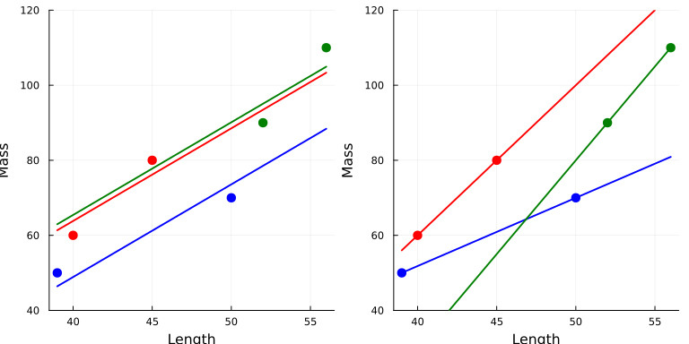

```julia
fm = lm(@formula(mass ~ pop + length), df)
c = coef(fm) # Extract coefficients vector
# Base Scatter Plot (equivalent to R's `plot(...)`)
# @df allows us to pass dataframe columns as symbols
p1 = @df df scatter(:length, :mass,
    group=:pop,
    color=[:red :blue :green], # Match R's col = c("red", "red", ...) by mapping to groups
    markershape=:circle,       # pch = 16 (solid circle)
    markersize=6,              # cex = 1.5 (scaled up size)
    markerstrokewidth=0,       # Removes outline to match pch = 16
    ylims=(40, 120),
    framestyle=:axes,          # frame = FALSE (removes top and right box edges)
    legend=false,               # R base plot doesn't draw a legend automatically
    ylabel="Mass",
    xlabel="Length"
)

# Add Regression Lines (equivalent to R's `abline(...)`)
# The idiomatic Julia way to do `abline` is to plot an anonymous function: x -> intercept + slope * x
plot!(p1, x -> c[1] + c[4]*x, color=(:red), linewidth=2)
plot!(p1, x -> (c[1] + c[2]) + c[4]*x, color=(:blue), linewidth=2)
plot!(p1, x -> (c[1] + c[3]) + c[4]*x, color=(:green), linewidth=2)

# Comparison plot with interactions
fm2 = lm(@formula(mass ~ pop * length), df)
c2 = coef(fm2)
p2 = @df df scatter(:length, :mass,
    group=:pop,
    color=[:red :blue :green],
    markershape=:circle,
    markersize=6,
    markerstrokewidth=0,
    ylims=(40, 120),
    framestyle=:axes,
    legend=false,
    ylabel="Mass",
    xlabel="Length"
)
# Base line for pop 1 (Intercept + Base length slope * x)
plot!(p2, x -> c2[1] + c2[4] * x, color=(:red), linewidth=2)

# Line for pop 2 (Intercept + pop2 diff) + (Base slope + pop2 interaction) * x
plot!(p2, x -> (c2[1] + c2[2]) + (c2[4] + c2[5]) * x, color=(:blue), linewidth=2)

# Line for pop 3 (Intercept + pop3 diff) + (Base slope + pop3 interaction) * x
plot!(p2, x -> (c2[1] + c2[3]) + (c2[4] + c2[6]) * x, color=(:green), linewidth=2)

plot(p1, p2, layout=(1, 2), size=(800, 400))
```

Now main effects only, with means parameterisation.

```julia
show(lm(@formula(mass ~ -1 + pop + length), df))
show(design_matrix_df(@formula(mass ~ -1 + pop + length), df))
```

```
StatsModels.TableRegressionModel{LinearModel{GLM.LmResp{Vector{Float64}}, GLM.DensePredChol{Float64, LinearAlgebra.CholeskyPivoted{Float64, Matrix{Float64}, Vector{Int64}}}}, Matrix{Float64}}(GLM.LinearModel{GLM.LmResp{Vector{Float64}}, GLM.DensePredChol{Float64, LinearAlgebra.CholeskyPivoted{Float6…

Coefficients:
─────────────────────────────────────────────────────────────────
        Coef.  Std. Error      t  Pr(>|t|)   Lower 95%  Upper 95%
─────────────────────────────────────────────────────────────────
x1  -34.9383     34.7899   -1.00    0.4210  -184.627    114.751
x2  -49.8765     36.392    -1.37    0.3041  -206.459    106.705
x3  -33.3333     44.0188   -0.76    0.5280  -222.731    156.064
x4    2.46914     0.80956   3.05    0.0928    -1.01412    5.95239
─────────────────────────────────────────────────────────────────
, ModelFrame{@NamedTuple{mass::Vector{Int64}, pop::CategoricalVector{Int64, UInt32, Int64, CategoricalValue{Int64, UInt32}, Union{}}, length::Vector{Int64}}, LinearModel}(mass ~ 0 + pop + length, StatsModels.Schema with 3 entries:
  length => length
  mass => mass
  pop => pop
, (mass = [60, 80, 50, 70, 90, 110], pop = CategoricalValue{Int64, UInt32}[CategoricalValue(CategoricalArrays.CategoricalPool{Int64, UInt32}([1, 2, 3]), 1), CategoricalValue(CategoricalArrays.CategoricalPool{Int64, UInt32}([1, 2, 3]), 1), CategoricalValue(CategoricalArrays.CategoricalPool{Int64, UIn…
 Row │ pop1     pop2     pop3     length
     │ Float64  Float64  Float64  Float64
─────┼────────────────────────────────────
   1 │     1.0      0.0      0.0     40.0
   2 │     1.0      0.0      0.0     45.0
   3 │     0.0      1.0      0.0     39.0
   4 │     0.0      1.0      0.0     50.0
   5 │     0.0      0.0      1.0     52.0
   6 │     0.0      0.0      1.0     56.0
```

And finally, ANCOVA with interactions and means parameterisation.

```julia
show(lm(@formula(mass ~ -1 + pop + pop &length), df))
show(design_matrix_df(@formula(mass ~ -1 + pop + pop & length), df))
```

```
StatsModels.TableRegressionModel{LinearModel{GLM.LmResp{Vector{Float64}}, GLM.DensePredChol{Float64, LinearAlgebra.CholeskyPivoted{Float64, Matrix{Float64}, Vector{Int64}}}}, Matrix{Float64}}(GLM.LinearModel{GLM.LmResp{Vector{Float64}}, GLM.DensePredChol{Float64, LinearAlgebra.CholeskyPivoted{Float6…

Coefficients:
─────────────────────────────────────────────────────────────────
         Coef.  Std. Error      t  Pr(>|t|)  Lower 95%  Upper 95%
─────────────────────────────────────────────────────────────────
x1  -100.0             Inf  -0.00    1.0000       -Inf        Inf
x2   -20.9091          Inf  -0.00    1.0000       -Inf        Inf
x3  -170.0             Inf  -0.00    1.0000       -Inf        Inf
x4     4.0             Inf   0.00    1.0000       -Inf        Inf
x5     1.81818         Inf   0.00    1.0000       -Inf        Inf
x6     5.0             Inf   0.00    1.0000       -Inf        Inf
─────────────────────────────────────────────────────────────────
, ModelFrame{@NamedTuple{mass::Vector{Int64}, pop::CategoricalVector{Int64, UInt32, Int64, CategoricalValue{Int64, UInt32}, Union{}}, length::Vector{Int64}}, LinearModel}(mass ~ 0 + pop + pop & length, StatsModels.Schema with 3 entries:
  length => length
  mass => mass
  pop => pop
, (mass = [60, 80, 50, 70, 90, 110], pop = CategoricalValue{Int64, UInt32}[CategoricalValue(CategoricalArrays.CategoricalPool{Int64, UInt32}([1, 2, 3]), 1), CategoricalValue(CategoricalArrays.CategoricalPool{Int64, UInt32}([1, 2, 3]), 1), CategoricalValue(CategoricalArrays.CategoricalPool{Int64, UIn…
 Row │ pop1     pop2     pop3     pop1 & length  pop2 & length  pop3 & length
     │ Float64  Float64  Float64  Float64        Float64        Float64
─────┼────────────────────────────────────────────────────────────────────────
   1 │     1.0      0.0      0.0           40.0            0.0            0.0
   2 │     1.0      0.0      0.0           45.0            0.0            0.0
   3 │     0.0      1.0      0.0            0.0           39.0            0.0
   4 │     0.0      1.0      0.0            0.0           50.0            0.0
   5 │     0.0      0.0      1.0            0.0            0.0           52.0
   6 │     0.0      0.0      1.0            0.0            0.0           56.0
```

That wraps up the code translations for this chapter. Much of this is very familiar to me, but the real eye opener has been seeing the design matrix for each example, and realising that for categorical variables the dummy variables act like an indicator function in maths. If it is `1` then the value of that term is the coefficient, and if it is `0`, the term does not contribute to the linear predictor. It is so simple when you see it like that.

This chapter was interesting and insightful, particularly in understanding how different parameterizations affect the interpretation of model coefficients, but the next chapter is when we start fitting Bayesian models. Since Turing.jl is primarily a HMC sampler, it should resemble the Stan code most, I would presume. However, I’m most familiar with jagsui and NIMBLE, so we shall see.